# Practicum 2

Jiaming Xu

# Problem 1:

### 1 & 2:

```r
library(tidyverse)
library(klaR)
library(gmodels)
library(broom)
library(psych)
```

Loading data from the local file since url needs update every time for accessing:

```r
df <- read.csv("german.csv")
glimpse(df)
```

```
## Rows: 1,000
## Columns: 21
## $ checking_balance     <chr> "< 0 DM", "1 - 200 DM", "unknown", "< 0 DM", "< 0…
## $ months_loan_duration <int> 6, 48, 12, 42, 24, 36, 24, 36, 12, 30, 12, 48, 12…
## $ credit_history       <chr> "critical", "repaid", "critical", "repaid", "dela…
## $ purpose              <chr> "radio/tv", "radio/tv", "education", "furniture",…
## $ amount               <int> 1169, 5951, 2096, 7882, 4870, 9055, 2835, 6948, 3…
## $ savings_balance      <chr> "unknown", "< 100 DM", "< 100 DM", "< 100 DM", "<…
## $ employment_length    <chr> "> 7 yrs", "1 - 4 yrs", "4 - 7 yrs", "4 - 7 yrs",…
## $ installment_rate     <int> 4, 2, 2, 2, 3, 2, 3, 2, 2, 4, 3, 3, 1, 4, 2, 4, 4…
## $ personal_status      <chr> "single male", "female", "single male", "single m…
## $ other_debtors        <chr> "none", "none", "none", "guarantor", "none", "non…
## $ residence_history    <int> 4, 2, 3, 4, 4, 4, 4, 2, 4, 2, 1, 4, 1, 4, 4, 2, 4…
## $ property             <chr> "real estate", "real estate", "real estate", "bui…
## $ age                  <int> 67, 22, 49, 45, 53, 35, 53, 35, 61, 28, 25, 24, 2…
## $ installment_plan     <chr> "none", "none", "none", "none", "none", "none", "…
## $ housing              <chr> "own", "own", "own", "for free", "for free", "for…
## $ existing_credits     <int> 2, 1, 1, 1, 2, 1, 1, 1, 1, 2, 1, 1, 1, 2, 1, 1, 2…
## $ default              <int> 1, 2, 1, 1, 2, 1, 1, 1, 1, 2, 2, 2, 1, 2, 1, 2, 1…
## $ dependents           <int> 1, 1, 2, 2, 2, 2, 1, 1, 1, 1, 1, 1, 1, 1, 1, 1, 1…
## $ telephone            <chr> "yes", "none", "none", "none", "none", "yes", "no…
## $ foreign_worker       <chr> "yes", "yes", "yes", "yes", "yes", "yes", "yes", …
## $ job                  <chr> "skilled employee", "skilled employee", "unskille…
```

```r
summary(df)
```

```
##  checking_balance   months_loan_duration credit_history       purpose
##  Length:1000        Min.   : 4.0         Length:1000        Length:1000
##  Class :character   1st Qu.:12.0         Class :character   Class :character
##  Mode  :character   Median :18.0         Mode  :character   Mode  :character
##                     Mean   :20.9
##                     3rd Qu.:24.0
##                     Max.   :72.0
##      amount      savings_balance    employment_length  installment_rate
##  Min.   :  250   Length:1000        Length:1000        Min.   :1.000
##  1st Qu.: 1366   Class :character   Class :character   1st Qu.:2.000
##  Median : 2320   Mode  :character   Mode  :character   Median :3.000
##  Mean   : 3271                                         Mean   :2.973
##  3rd Qu.: 3972                                         3rd Qu.:4.000
##  Max.   :18424                                         Max.   :4.000
##  personal_status    other_debtors      residence_history   property
##  Length:1000        Length:1000        Min.   :1.000     Length:1000
##  Class :character   Class :character   1st Qu.:2.000     Class :character
##  Mode  :character   Mode  :character   Median :3.000     Mode  :character
##                                        Mean   :2.845
##                                        3rd Qu.:4.000
##                                        Max.   :4.000
##       age        installment_plan     housing          existing_credits
##  Min.   :19.00   Length:1000        Length:1000        Min.   :1.000
##  1st Qu.:27.00   Class :character   Class :character   1st Qu.:1.000
##  Median :33.00   Mode  :character   Mode  :character   Median :1.000
##  Mean   :35.55                                         Mean   :1.407
##  3rd Qu.:42.00                                         3rd Qu.:2.000
##  Max.   :75.00                                         Max.   :4.000
##     default      dependents     telephone         foreign_worker
##  Min.   :1.0   Min.   :1.000   Length:1000        Length:1000
##  1st Qu.:1.0   1st Qu.:1.000   Class :character   Class :character
##  Median :1.0   Median :1.000   Mode  :character   Mode  :character
##  Mean   :1.3   Mean   :1.155
##  3rd Qu.:2.0   3rd Qu.:1.000
##  Max.   :2.0   Max.   :2.000
##      job
##  Length:1000
##  Class :character
##  Mode  :character
##
##
##
```

### 3:

Since default variable only has 1 and two, I can use ifelse to replace 1 with ‘good’, 2 with ‘bad’.

```r
unique(df$default)
```

```
## [1] 1 2
```

```r
df1 <- mutate(df, default = ifelse(default == 1, "Good", "Bad"))
```

### 4:

```r
set.seed(7)
train <- sample(nrow(df1), floor(0.7*nrow(df1)))
df1_train <- df1[train, ]
df1_test <-  df1[-train, ]
table(df1_train$default)
```

```
##
##  Bad Good
##  205  495
```

```r
table(df1_test$default)
```

```
##
##  Bad Good
##   95  205
```

### 5:

1. Select Status of existing checking account (1), Credit history (3), Purpose (4), Credit amount (5), Installment rate in percentage of disposable income (8), Personal Status (9), Property (12), Age (13), Number of existing credits at this bank (16) and Job (21), save new data frame as df2.
2. Change age and amount variable to categorical using cut function. 6 bins for age and 5 bins for amount variable. Change installment_rate and existing_credits as factor.
3. Divide df2_lgr into train and test subsets, use NaiveBayes function to predict, save to default.nb.
4. Get prediction results as vector using predict function.

```r
df2 <- df1[, c(1,3,4,5,8,9,12,13,16,17,21)]

df2_lgr <- df2 %>%
  mutate( age = cut(age, breaks = 6, labels = c(1,2,3,4,5,6))) %>%
  mutate( amount = cut(amount, breaks = 5, labels = c(1,2,3,4,5))) %>%
  mutate( installment_rate = factor(installment_rate)) %>%
  mutate( existing_credits = factor(existing_credits))

df2_train <- df2_lgr[train, ]
df2_test <- df2_lgr[-train, ]

default.nb <- NaiveBayes(factor(default) ~ ., data = df2_train )

predict.nb <- predict(default.nb, df2_test[, -10])
```

### 6:

Using CrossTable to build up a confusion matrix. 55 FP and 20 FN, 225 correct prediction over 300 testing set, overall 75% accuracy. 55 FP is relatively high to put bank at risk if lending money to risky users.

```r
CrossTable(predict.nb$class, df2_test$default, dnn = c('predicted','actual'))
```

```
##
##
##    Cell Contents
## |-------------------------|
## |                       N |
## | Chi-square contribution |
## |           N / Row Total |
## |           N / Col Total |
## |         N / Table Total |
## |-------------------------|
##
##
## Total Observations in Table:  300
##
##
##              | actual
##    predicted |       Bad |      Good | Row Total |
## -------------|-----------|-----------|-----------|
##          Bad |        40 |        20 |        60 |
##              |    23.211 |    10.756 |           |
##              |     0.667 |     0.333 |     0.200 |
##              |     0.421 |     0.098 |           |
##              |     0.133 |     0.067 |           |
## -------------|-----------|-----------|-----------|
##         Good |        55 |       185 |       240 |
##              |     5.803 |     2.689 |           |
##              |     0.229 |     0.771 |     0.800 |
##              |     0.579 |     0.902 |           |
##              |     0.183 |     0.617 |           |
## -------------|-----------|-----------|-----------|
## Column Total |        95 |       205 |       300 |
##              |     0.317 |     0.683 |           |
## -------------|-----------|-----------|-----------|
##
##
```

### 7:

1. Change Good to 1, Bad to 0 for applying logistic regression
2. Define train and test subsets.
3. Use glm function to apply Logistic Regression, using binomial regression.
4. Take a look of prediction results.

```r
df3 <- df2 %>%
  mutate( default = ifelse( default == 'Bad', 0, 1))

df3_train <- df3[ train,]
df3_test <- df3[ -train,]

default.lr <- glm(default ~ ., data = df3_train, family = 'binomial')
table(augment(default.lr, newdata = df3_test, type.predict = 'response')$.fitted > 0.5)
```

```
##
## FALSE  TRUE
##    53   247
```

```r
table(df3_test$default)
```

```
##
##   0   1
##  95 205
```

### 8:

1. Use augment with type.predict = ‘response’ to get response variable prediction, then use ifelse to make results as binomial variables.
2. Use CrossTable to generate the confusion table.

The results show that the overall accuracy is 224/300 ~ 75% which is identical to NaiveBayes prediction. Also similar as NaiveBayes, FP = 59 among testing dataset which is also worth to consider.

```r
default.lr.prediction <- ifelse(augment(default.lr, newdata = df3_test, type.predict = 'response')$.fitted > 0.5, 1, 0)
CrossTable(default.lr.prediction, df3_test$default, dnn = c('predicted','actual'))
```

```
##
##
##    Cell Contents
## |-------------------------|
## |                       N |
## | Chi-square contribution |
## |           N / Row Total |
## |           N / Col Total |
## |         N / Table Total |
## |-------------------------|
##
##
## Total Observations in Table:  300
##
##
##              | actual
##    predicted |         0 |         1 | Row Total |
## -------------|-----------|-----------|-----------|
##            0 |        36 |        17 |        53 |
##              |    22.003 |    10.196 |           |
##              |     0.679 |     0.321 |     0.177 |
##              |     0.379 |     0.083 |           |
##              |     0.120 |     0.057 |           |
## -------------|-----------|-----------|-----------|
##            1 |        59 |       188 |       247 |
##              |     4.721 |     2.188 |           |
##              |     0.239 |     0.761 |     0.823 |
##              |     0.621 |     0.917 |           |
##              |     0.197 |     0.627 |           |
## -------------|-----------|-----------|-----------|
## Column Total |        95 |       205 |       300 |
##              |     0.317 |     0.683 |           |
## -------------|-----------|-----------|-----------|
##
##
```

### 9, 10:

Decision Tree can only applied to categorical variables, while regression tree and model trees can be applied to continuous variables. However, regression tree do not use linear regression methods they make predictions based on the average value of examples that reach a leaf. Therefore, continuous variables are used for regression trees, and categorified data used for decision trees.

In my opinion, these two trees don’t have too many differences therefore provide similar accuracy. The advantage of regression tree is categorification of continuous data is not necessary, therefore I prefer regression tree for less data preparation process.

```r
library(rpart)
library(C50)

default.rp <- rpart(default ~ ., data = df2[train, ])
default.c50 <- C5.0(factor(default) ~. , data = df2_lgr[train, ])

predict.rp <- predict(default.rp ,df2[-train, ])
predict.c50 <- predict(default.c50, df2_lgr[-train, ])
```

### 11:

CrossTable is used here. As we can see, two trees don’t give different predictions, regression trees provide silightly better results.

```r
CrossTable(ifelse(predict.rp[,1] > .5, 'Bod', "Good"), df2_lgr[-train, ]$default)
```

```
##
##
##    Cell Contents
## |-------------------------|
## |                       N |
## | Chi-square contribution |
## |           N / Row Total |
## |           N / Col Total |
## |         N / Table Total |
## |-------------------------|
##
##
## Total Observations in Table:  300
##
##
##                                              | df2_lgr[-train, ]$default
## ifelse(predict.rp[, 1] > 0.5, "Bod", "Good") |       Bad |      Good | Row Total |
## ---------------------------------------------|-----------|-----------|-----------|
##                                          Bod |        29 |        18 |        47 |
##                                              |    13.389 |     6.205 |           |
##                                              |     0.617 |     0.383 |     0.157 |
##                                              |     0.305 |     0.088 |           |
##                                              |     0.097 |     0.060 |           |
## ---------------------------------------------|-----------|-----------|-----------|
##                                         Good |        66 |       187 |       253 |
##                                              |     2.487 |     1.153 |           |
##                                              |     0.261 |     0.739 |     0.843 |
##                                              |     0.695 |     0.912 |           |
##                                              |     0.220 |     0.623 |           |
## ---------------------------------------------|-----------|-----------|-----------|
##                                 Column Total |        95 |       205 |       300 |
##                                              |     0.317 |     0.683 |           |
## ---------------------------------------------|-----------|-----------|-----------|
##
##
```

```r
CrossTable(predict.c50, df2_lgr[-train, ]$default)
```

```
##
##
##    Cell Contents
## |-------------------------|
## |                       N |
## | Chi-square contribution |
## |           N / Row Total |
## |           N / Col Total |
## |         N / Table Total |
## |-------------------------|
##
##
## Total Observations in Table:  300
##
##
##              | df2_lgr[-train, ]$default
##  predict.c50 |       Bad |      Good | Row Total |
## -------------|-----------|-----------|-----------|
##          Bad |        21 |        16 |        37 |
##              |     7.355 |     3.409 |           |
##              |     0.568 |     0.432 |     0.123 |
##              |     0.221 |     0.078 |           |
##              |     0.070 |     0.053 |           |
## -------------|-----------|-----------|-----------|
##         Good |        74 |       189 |       263 |
##              |     1.035 |     0.480 |           |
##              |     0.281 |     0.719 |     0.877 |
##              |     0.779 |     0.922 |           |
##              |     0.247 |     0.630 |           |
## -------------|-----------|-----------|-----------|
## Column Total |        95 |       205 |       300 |
##              |     0.317 |     0.683 |           |
## -------------|-----------|-----------|-----------|
##
##
```

### 12:

1. Build getmode function and predictCreditRisk function. predictCreditRisk can take dataset as input.
2. Decide the final prediction by finding the mode of three predictions.

```r
getmode <- function(v) {
   uniqv <- unique(v)
   uniqv[which.max(tabulate(match(v, uniqv)))]
}

predictCreditRisk <- function(x){
  x.lgr <- x

  # turn age and amount to categorical variables by using bins predefined. For
  # categorical functions NaiveBayes and rpart.
  age.bins <- seq(18.9, 75.1, length.out=7)
  amount.bins <- seq(min(df2$amount), max(df2$amount), length.out=6)

  x.lgr$age <- factor(sapply(x$age, function(x){sum(x > age.bins)}))
  x.lgr$amount <- factor(sapply(x$amount, function(x){sum(x > amount.bins)}))

  x.lgr <- x.lgr %>%
    mutate(installment_rate = factor(installment_rate)) %>%
    mutate(existing_credits = factor(existing_credits))

  set.seed(7)
  predict.nb <- predict(default.nb, x.lgr)$class %>% as.character()
  predict.rp <- ifelse(predict(default.rp, x)[,1 ] > .5,
                       'Bad', 'Good') %>% as.character()
  predict.c50 <- predict(default.c50, x.lgr) %>% as.character()
  predict.all <- cbind(predict.nb,predict.rp,predict.c50)
  apply(predict.all,1, getmode)
}

predictCreditRisk(df2[1:10,])
```

```
##  [1] "Good" "Good" "Good" "Good" "Bad"  "Good" "Good" "Good" "Good" "Good"
```

### 13:

Assuming amount = 5000, installment_rate = 1, age = 47, other missing info replaced by the mode of that variable. Prediction shows this user is good for a loan.

```r
new_obj <- data.frame( 'age' = 47, 'personal_status' = 'single male',
                       'credit_history' = 'critical', 'property' = "real estate",
                       'purpose' = 'car (new)', 'checking_balance' = 'unknown',
                       'amount' = 5000, 'installment_rate' = 1, 'existing_credits' = getmode(df2$existing_credits), 'job' = getmode(df2$job))

predictCreditRisk(new_obj)
```

```
## [1] "Good"
```

# Problem 2:

### 1:

1. Loading data, select all continuous variables and two categorical variables, num_of_doors and num_of_cylinders.
2. Replace missing values by NA. Change the name of variables. Change written number to numeric of number_of_doors and num_of_cylinders. Change all columns to numeric type.

```r
df <- read_csv("https://archive.ics.uci.edu/ml/machine-learning-databases/autos/imports-85.data", col_names = FALSE)
cars.df <- df[, c(2,6,10:14,16,17,19:26)]
colnames(cars.df) <- c("normalized-losses", "num_of_doors", "wheel-base",
                       "length","width","height","curb-weight","num_of_cylinders",
                       "engine-size","bore","stroke","compression-ratio","horsepower",
                       "peak-rpm","city-mpg","highway-mpg","price")
cars.df[cars.df == '?'] <- NA
cars.df <- cars.df %>%
  mutate( num_of_cylinders = str_replace_all(num_of_cylinders,
                                             c("two"='2',"three"='3',"four"='4',
                                               "five"='5', "six" = '6',
                                               "eight"='8', "twelve"='12'))) %>%
  mutate( num_of_doors = str_replace_all(num_of_doors, c("two"='2',"four"='4')))

cars.df <- sapply(cars.df, as.numeric) %>% as_tibble()
glimpse(cars.df)
```

```
## Rows: 205
## Columns: 17
## $ `normalized-losses` <dbl> NA, NA, NA, 164, 164, NA, 158, NA, 158, NA, 192, 1…
## $ num_of_doors        <dbl> 2, 2, 2, 4, 4, 2, 4, 4, 4, 2, 2, 4, 2, 4, 4, 4, 2,…
## $ `wheel-base`        <dbl> 88.6, 88.6, 94.5, 99.8, 99.4, 99.8, 105.8, 105.8, …
## $ length              <dbl> 168.8, 168.8, 171.2, 176.6, 176.6, 177.3, 192.7, 1…
## $ width               <dbl> 64.1, 64.1, 65.5, 66.2, 66.4, 66.3, 71.4, 71.4, 71…
## $ height              <dbl> 48.8, 48.8, 52.4, 54.3, 54.3, 53.1, 55.7, 55.7, 55…
## $ `curb-weight`       <dbl> 2548, 2548, 2823, 2337, 2824, 2507, 2844, 2954, 30…
## $ num_of_cylinders    <dbl> 4, 4, 6, 4, 5, 5, 5, 5, 5, 5, 4, 4, 6, 6, 6, 6, 6,…
## $ `engine-size`       <dbl> 130, 130, 152, 109, 136, 136, 136, 136, 131, 131, …
## $ bore                <dbl> 3.47, 3.47, 2.68, 3.19, 3.19, 3.19, 3.19, 3.19, 3.…
## $ stroke              <dbl> 2.68, 2.68, 3.47, 3.40, 3.40, 3.40, 3.40, 3.40, 3.…
## $ `compression-ratio` <dbl> 9.00, 9.00, 9.00, 10.00, 8.00, 8.50, 8.50, 8.50, 8…
## $ horsepower          <dbl> 111, 111, 154, 102, 115, 110, 110, 110, 140, 160, …
## $ `peak-rpm`          <dbl> 5000, 5000, 5000, 5500, 5500, 5500, 5500, 5500, 55…
## $ `city-mpg`          <dbl> 21, 21, 19, 24, 18, 19, 19, 19, 17, 16, 23, 23, 21…
## $ `highway-mpg`       <dbl> 27, 27, 26, 30, 22, 25, 25, 25, 20, 22, 29, 29, 28…
## $ price               <dbl> 13495, 16500, 16500, 13950, 17450, 15250, 17710, 1…
```

### 2:

```r
step(lm(price ~ . , data = drop_na(cars.df)), direction = 'backward',   trace = 0) %>% summary()
```

```
##
## Call:
## lm(formula = price ~ `normalized-losses` + `wheel-base` + length +
##     width + `curb-weight` + num_of_cylinders + horsepower, data = drop_na(cars.df))
##
## Residuals:
##     Min      1Q  Median      3Q     Max
## -5852.4 -1289.5  -160.1   979.4  7158.1
##
## Coefficients:
##                       Estimate Std. Error t value Pr(>|t|)
## (Intercept)         -67134.496  11288.022  -5.947 1.82e-08 ***
## `normalized-losses`      9.414      5.739   1.640 0.103026
## `wheel-base`           189.567     86.682   2.187 0.030287 *
## length                 -88.677     42.598  -2.082 0.039054 *
## width                  788.133    217.336   3.626 0.000393 ***
## `curb-weight`            6.156      1.185   5.194 6.56e-07 ***
## num_of_cylinders      1231.638    394.460   3.122 0.002151 **
## horsepower              21.090     11.368   1.855 0.065517 .
## ---
## Signif. codes:  0 '***' 0.001 '**' 0.01 '*' 0.05 '.' 0.1 ' ' 1
##
## Residual standard error: 2353 on 151 degrees of freedom
## Multiple R-squared:  0.8469, Adjusted R-squared:  0.8398
## F-statistic: 119.3 on 7 and 151 DF,  p-value: < 2.2e-16
```

```r
cars.no.df <- cars.df %>%
  mutate( z = (price - mean(price, na.rm=T))/sd(price, na.rm = T) ) %>%
  filter( abs(z) <= 3) %>%
  mutate( z = (width - mean(width, na.rm=T))/sd(width, na.rm = T) ) %>%
  filter( abs(z) <= 3) %>%
  mutate( z = (`curb-weight` - mean(`curb-weight`, na.rm=T))/sd(`curb-weight`, na.rm = T) ) %>%
  filter( abs(z) <= 3) %>%
  mutate( z = (num_of_cylinders - mean(num_of_cylinders, na.rm=T))/sd(num_of_cylinders, na.rm = T) ) %>%
  filter( abs(z) <= 3) %>%
  mutate( z = (horsepower - mean(horsepower, na.rm=T))/sd(horsepower, na.rm = T) ) %>%
  filter( abs(z) <= 3) %>%
  dplyr::select( -z)
```

### 3:

The dataset is too large to make output of pairs.panels visible, so I divided into to figures.

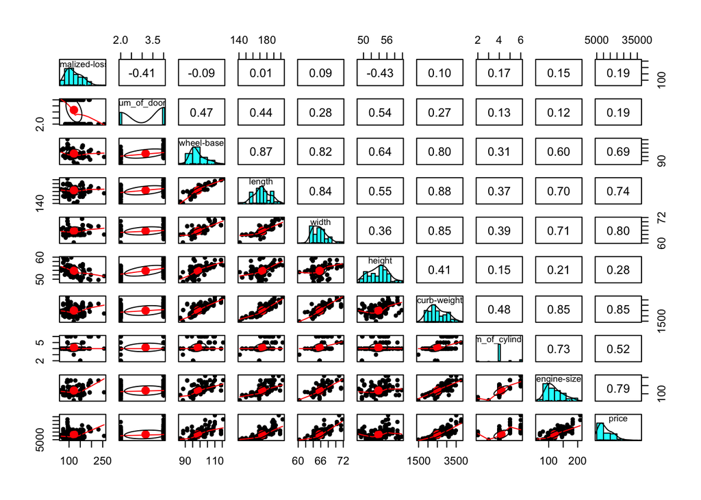

```r
pairs.panels(cars.no.df[, c(1:9,17)])
```

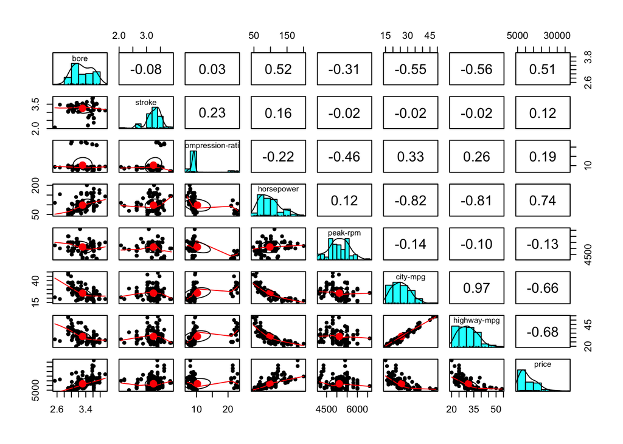

```r
pairs.panels(cars.no.df[, c(10:17)])
```

highway-mpg and city-mpg looks like inverse relationship with price. And in the figure below we can see price is linear relationship with reciprocal of highway-mpg and city-mpg.

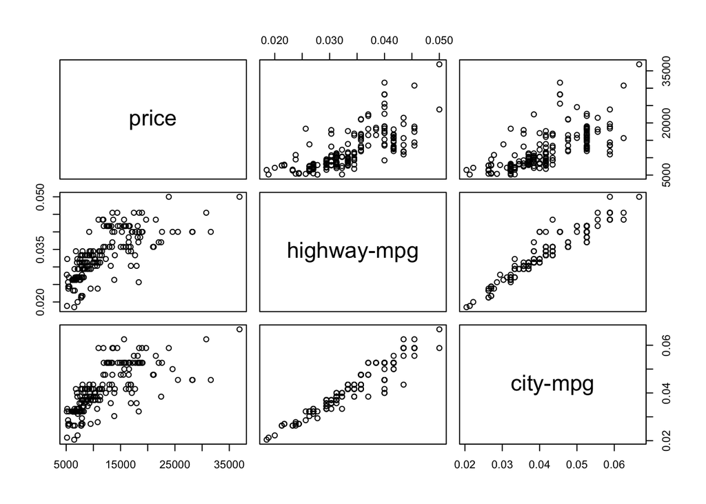

```r
pairs(cbind(cars.no.df[,'price'], 1/cars.no.df[,'highway-mpg'], 1/cars.no.df[,'city-mpg']))
```

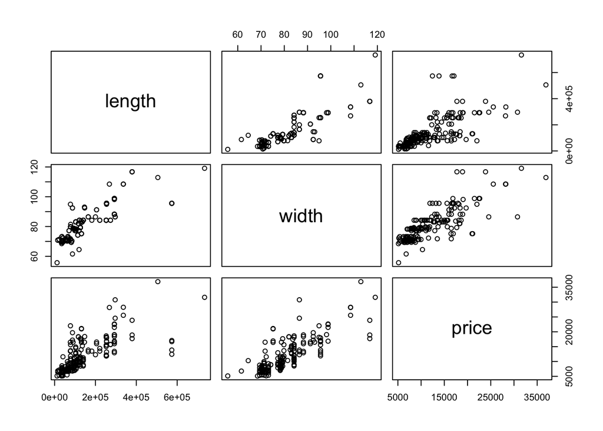

```r
pairs(cbind(exp(cars.no.df[,'length']/15), exp(cars.no.df[,'width']/15), (cars.no.df[, 'price'])))
```

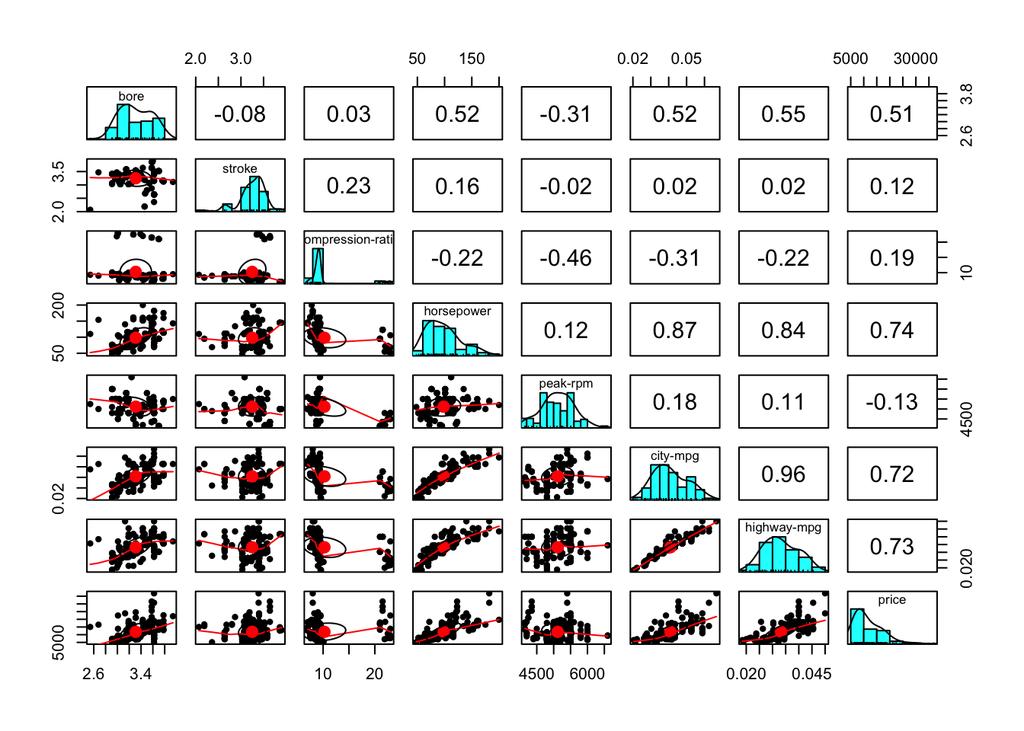

```r
cars.tx <- cars.no.df %>%
  mutate( `highway-mpg` = 1/`highway-mpg`) %>%
  mutate( `city-mpg` = 1/ `city-mpg`) %>%
  mutate( width = exp(width/5)) %>%
  mutate( length = exp(length/15))

pairs.panels(cars.tx[, c(10:17)])
```

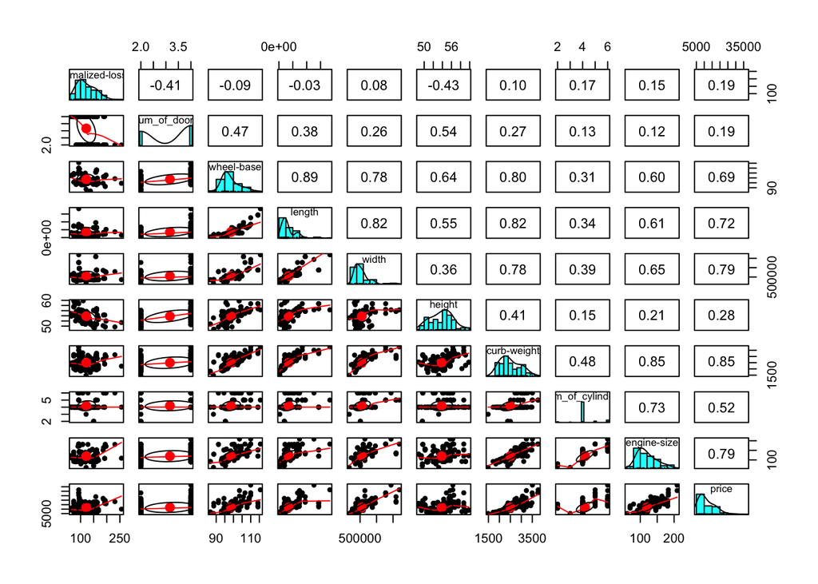

```r
pairs.panels(cars.tx[, c(1:9,17)])
```

Now the panels are linearized.

### 4:

```r
cor(x = cars.no.df, use='complete.obs')
```

```
##                   normalized-losses num_of_doors wheel-base      length
## normalized-losses        1.00000000  -0.39618384 -0.0732285  0.02336782
## num_of_doors            -0.39618384   1.00000000  0.4248848  0.41661780
## wheel-base              -0.07322850   0.42488483  1.0000000  0.86960451
## length                   0.02336782   0.41661780  0.8696045  1.00000000
## width                    0.09499348   0.26655780  0.8325194  0.84092197
## height                  -0.41029353   0.46701781  0.5811568  0.52635990
## curb-weight              0.10858655   0.27954134  0.8228514  0.87666119
## num_of_cylinders         0.27223910   0.01871990  0.3263755  0.38157818
## engine-size              0.19818181   0.10355970  0.6691519  0.74163260
## bore                    -0.03943223   0.21553584  0.5755800  0.64136225
## stroke                   0.05338898  -0.05087042  0.1158964  0.07960074
## compression-ratio       -0.12370564   0.11543792  0.3088120  0.19912006
## horsepower               0.28246709   0.03265747  0.5034824  0.65919925
## peak-rpm                 0.24556274  -0.17272948 -0.2852275 -0.22405800
## city-mpg                -0.22630296  -0.17422594 -0.5769268 -0.71729638
## highway-mpg             -0.17723299  -0.17334555 -0.6126441 -0.71868203
## price                    0.19141328   0.19482196  0.7708349  0.77862010
##                         width       height curb-weight num_of_cylinders
## normalized-losses  0.09499348 -0.410293527   0.1085865      0.272239101
## num_of_doors       0.26655780  0.467017811   0.2795413      0.018719900
## wheel-base         0.83251942  0.581156811   0.8228514      0.326375511
## length             0.84092197  0.526359900   0.8766612      0.381578176
## width              1.00000000  0.334695620   0.8638213      0.456113315
## height             0.33469562  1.000000000   0.4270857     -0.001620483
## curb-weight        0.86382133  0.427085712   1.0000000      0.547958302
## num_of_cylinders   0.45611331 -0.001620483   0.5479583      1.000000000
## engine-size        0.77431711  0.180869230   0.8796917      0.729950370
## bore               0.56953839  0.267332524   0.6511216      0.107093090
## stroke             0.17391752 -0.088921062   0.1250422      0.113289268
## compression-ratio  0.28358275  0.229389257   0.2592218      0.101261653
## horsepower         0.66111504  0.061834394   0.7727500      0.602390374
## peak-rpm          -0.21765869 -0.257872799  -0.2457257     -0.088898890
## city-mpg          -0.64964057 -0.227038225  -0.7523050     -0.459739342
## highway-mpg       -0.67343595 -0.260724199  -0.7766266     -0.482367973
## price              0.83918215  0.324254621   0.8842688      0.557589684
##                   engine-size        bore       stroke compression-ratio
## normalized-losses   0.1981818 -0.03943223  0.053388977       -0.12370564
## num_of_doors        0.1035597  0.21553584 -0.050870421        0.11543792
## wheel-base          0.6691519  0.57558000  0.115896449        0.30881205
```

[output cut: 17 more lines]

```
## wheel-base         0.50348239 -0.285227465 -0.57692676 -0.61264407  0.7708349
## length             0.65919925 -0.224057999 -0.71729638 -0.71868203  0.7786201
## width              0.66111504 -0.217658686 -0.64964057 -0.67343595  0.8391821
## height             0.06183439 -0.257872799 -0.22703823 -0.26072420  0.3242546
## curb-weight        0.77275000 -0.245725665 -0.75230504 -0.77662658  0.8842688
## num_of_cylinders   0.60239037 -0.088898890 -0.45973934 -0.48236797  0.5575897
## engine-size        0.81036734 -0.276947914 -0.69852978 -0.70399588  0.8055341
## bore               0.55448046 -0.306136410 -0.58474242 -0.58680658  0.5461780
## stroke             0.10886511  0.002311259  0.01390180  0.02313802  0.1152378
## compression-ratio -0.15302464 -0.424171117  0.27284489  0.21443082  0.2590931
## horsepower         1.00000000  0.100597597 -0.82975793 -0.81793768  0.7462063
## peak-rpm           0.10059760  1.000000000 -0.07285725 -0.05564826 -0.1489875
## city-mpg          -0.82975793 -0.072857250  1.00000000  0.97132988 -0.6841016
## highway-mpg       -0.81793768 -0.055648262  0.97132988  1.00000000 -0.7043106
## price              0.74620631 -0.148987546 -0.68410164 -0.70431063  1.0000000
```

### 5:

The sample is applied to each dataset separately since they don’t have the same number of rows, then dividing them into train and test subsets.

```r
set.seed(7)
train <- sample(nrow(cars.df), 0.7*nrow(cars.df))
train.no <- sample(nrow(cars.no.df), 0.7*nrow(cars.no.df))
train.tx <- sample(nrow(cars.tx), 0.7*nrow(cars.tx))

cars.training <- cars.df[train,]
cars.testing <- cars.df[-train,]
cars.no.training <- cars.no.df[train.no,]
cars.no.testing <- cars.no.df[-train.no,]
cars.tx.training <- cars.tx[train.tx,]
cars.tx.testing <- cars.tx[-train.tx,]
```

### 6:

I made a backward p value elimination function for “lm” or “glm” functions called lm_backelimq(), which prune variables with p values greater than specific value (default is 0.1).

Also, I used step() function for AIC backward elimination. Rows containing NA are removed since step function requries the structure of data set at constant during backward prune process.

```r
set.seed(7)

cars.training <- drop_na(cars.training)
cars.no.training <- drop_na(cars.no.training)
cars.tx.training <- drop_na(cars.tx.training)

cars.testing <- drop_na(cars.testing)
cars.no.testing <- drop_na(cars.no.testing)
cars.tx.testing <- drop_na(cars.tx.testing)


lm_backelimq <- function(x_train, keep = FALSE, loop = 10, trace = 1, p = 0.1){
  test <- x_train
  x.lm <- lm(formula = price ~ . , data = test)
  for (q in 1:loop) {
    n = 1
    if (trace == 1) {
      print(q)
      print(summary(x.lm)$coefficients)
    }
    lm.summary <- summary(x.lm)$coefficients[, 4]
    p.to.drop <- names(sort(lm.summary, decreasing = TRUE))[n]
    ## Jump to second or third highest p value if highest is in keep input.
    while(any(p.to.drop == keep)){
      n = n + 1
      p.to.drop <- names(sort(lm.summary, decreasing = TRUE))[n]
    }

    if ( lm.summary[p.to.drop] > p ) {
      p.to.drop <- str_remove_all(p.to.drop, '`')
      test <- dplyr::select(test, -p.to.drop)
    }
    x.lm <- lm(formula = price ~ . , data = test)
  }
  x.lm
}

cars.lm.p <- lm_backelimq(cars.df, trace = 0, p = 0.05, loop = 20)
```

```
## Note: Using an external vector in selections is ambiguous.
## ℹ Use `all_of(p.to.drop)` instead of `p.to.drop` to silence this message.
## ℹ See <https://tidyselect.r-lib.org/reference/faq-external-vector.html>.
```

```r
cars.no.lm.p <- lm_backelimq(cars.no.df, trace = 0, p = 0.05, loop = 20)
cars.tx.lm.p <- lm_backelimq(cars.tx, trace = 0 , p = 0.05, loop = 20)

## draft

cars.lm.aic <- step(lm(price ~ . , data = cars.training), direction = 'backward',   trace = 0)
cars.no.lm.aic <- step(lm(price ~ ., data = cars.no.training), direction = 'backward',   trace = 0)
cars.tx.lm.aic <- step(lm(price ~ ., data = cars.tx.training), direction = 'backward',   trace = 0)
```

### 7:

```r
set.seed(7)
cars.rp <- rpart(price ~ ., data = cars.df)
cars.no.rp <- rpart(price ~ ., data = cars.no.df)
cars.tx.rp <- rpart(price ~ ., data = cars.tx)
```

### 8:

#### Pridiction evaluation:

```r
set.seed(7)
MASE <- function(x, y){
  return (sum(abs(x - y))/(length(y)-1))
}

RMSE <- function(x, y){
  return ( sqrt( mean( (x - y) ^2)))
}

summary_table <- tibble( 'ARS' = c(summary(cars.lm.p)$adj.r.squared, summary(cars.no.lm.p)$adj.r.squared,
                       summary(cars.tx.lm.p)$adj.r.squared, summary(cars.lm.aic)$adj.r.squared,
                       summary(cars.no.lm.aic)$adj.r.squared, summary(cars.tx.lm.aic)$adj.r.squared,
                       NA,NA,NA),
             'MASE' = c(MASE(predict(cars.lm.p, newdata = cars.testing), cars.testing$price),
                        MASE(predict(cars.no.lm.p, newdata = cars.no.testing), cars.no.testing$price),
                        MASE(predict(cars.tx.lm.p, newdata = cars.tx.testing), cars.tx.testing$price),
                        MASE(predict(cars.lm.aic, newdata = cars.testing), cars.testing$price),
                        MASE(predict(cars.no.lm.aic, newdata = cars.no.testing), cars.no.testing$price),
                        MASE(predict(cars.tx.lm.aic, newdata = cars.tx.testing), cars.tx.testing$price),
                        MASE(predict(cars.rp, newdata = cars.testing), cars.testing$price),
                        MASE(predict(cars.no.rp, newdata = cars.no.testing), cars.no.testing$price),
                        MASE(predict(cars.tx.rp, newdata = cars.tx.testing), cars.tx.testing$price)),
             'RMSE' = c(RMSE(predict(cars.lm.p, newdata = cars.testing), cars.testing$price),
                        RMSE(predict(cars.no.lm.p, newdata = cars.no.testing), cars.no.testing$price),
                        RMSE(predict(cars.tx.lm.p, newdata = cars.tx.testing), cars.tx.testing$price),
                        RMSE(predict(cars.lm.aic, newdata = cars.testing), cars.testing$price),
                        RMSE(predict(cars.no.lm.aic, newdata = cars.no.testing), cars.no.testing$price),
                        RMSE(predict(cars.tx.lm.aic, newdata = cars.tx.testing), cars.tx.testing$price),
                        RMSE(predict(cars.rp, newdata = cars.testing), cars.testing$price),
                        RMSE(predict(cars.no.rp, newdata = cars.no.testing), cars.no.testing$price),
                        RMSE(predict(cars.tx.rp, newdata = cars.tx.testing), cars.tx.testing$price)),

             ) %>% as.data.frame()
rownames(summary_table) <- c('p_elim_df', 'p_elim_no', 'p_elim_tx',
                 'aic_elim_df', 'aic_elim_no', 'aic_elim_tx',
                 'reg_tree_df', 'reg_tree_no', 'reg_tree_tx')
summary_table
```

|  | ARS | MASE | RMSE |
| --- | --- | --- | --- |
| p_elim_df | 0.7772423 | 2304.710 | 2815.262 |
| p_elim_no | 0.8259724 | 1393.977 | 2038.659 |
| p_elim_tx | 0.8022448 | 1578.988 | 2058.414 |
| aic_elim_df | 0.8475268 | 2109.880 | 3060.339 |
| aic_elim_no | 0.8527024 | 1861.995 | 2859.075 |
| aic_elim_tx | 0.8407162 | 1589.525 | 2300.719 |
| reg_tree_df | NA | 1921.473 | 2606.267 |
| reg_tree_no | NA | 1571.636 | 2104.560 |
| reg_tree_tx | NA | 1774.602 | 2376.369 |

In general, Regression Tree yield a better prediction than multi-linear-regressions on less-processed datasets. AIC backward eliminated linear model did a better job than Regression Tree since four non-linear variables were manipulated to linear relationships with target - price. Also, there’s no need to linearize dataset for Regression Tree.

### 9:

Use all features as inputs for multivariable linear regression.

```r
set.seed(7)
cars.lm <- lm( price ~ ., data = cars.df)
cars.no.lm <- lm( price ~ ., data = cars.no.df)
cars.tx.lm <- lm( price ~ ., data = cars.tx)
```

```r
summary(cars.lm)
```

```
##
## Call:
## lm(formula = price ~ ., data = cars.df)
##
## Residuals:
##     Min      1Q  Median      3Q     Max
## -5755.2 -1185.3  -191.5   817.2  7329.7
##
## Coefficients:
##                       Estimate Std. Error t value Pr(>|t|)
## (Intercept)         -6.625e+04  1.732e+04  -3.826 0.000195 ***
## `normalized-losses`  7.550e+00  7.141e+00   1.057 0.292150
## num_of_doors        -6.877e+01  2.626e+02  -0.262 0.793817
## `wheel-base`         1.951e+02  9.307e+01   2.097 0.037797 *
## length              -8.622e+01  4.899e+01  -1.760 0.080582 .
## width                7.661e+02  2.349e+02   3.261 0.001389 **
## height               3.002e+01  1.381e+02   0.217 0.828223
## `curb-weight`        5.459e+00  1.672e+00   3.265 0.001372 **
## num_of_cylinders     7.976e+02  7.744e+02   1.030 0.304814
## `engine-size`        2.496e+01  3.096e+01   0.806 0.421604
## bore                -7.092e+02  1.539e+03  -0.461 0.645519
## stroke              -1.314e+03  9.396e+02  -1.398 0.164297
## `compression-ratio`  9.685e+01  7.849e+01   1.234 0.219284
## horsepower           2.499e+01  1.681e+01   1.486 0.139391
## `peak-rpm`           7.245e-01  5.702e-01   1.270 0.205989
## `city-mpg`          -1.755e+01  1.598e+02  -0.110 0.912706
## `highway-mpg`        3.116e+01  1.464e+02   0.213 0.831752
## ---
## Signif. codes:  0 '***' 0.001 '**' 0.01 '*' 0.05 '.' 0.1 ' ' 1
##
## Residual standard error: 2387 on 142 degrees of freedom
##   (46 observations deleted due to missingness)
## Multiple R-squared:  0.8518, Adjusted R-squared:  0.8351
## F-statistic: 50.99 on 16 and 142 DF,  p-value: < 2.2e-16
```

```r
summary(cars.tx.lm)
```

```
##
## Call:
## lm(formula = price ~ ., data = cars.tx)
##
## Residuals:
##     Min      1Q  Median      3Q     Max
## -5117.0 -1079.0  -157.1   872.1  6742.0
##
## Coefficients:
##                       Estimate Std. Error t value Pr(>|t|)
## (Intercept)         -2.279e+04  1.079e+04  -2.113 0.036404 *
## `normalized-losses`  9.333e+00  6.421e+00   1.453 0.148342
## num_of_doors        -1.184e+02  2.250e+02  -0.526 0.599430
## `wheel-base`         1.221e+02  8.459e+01   1.443 0.151261
## length               3.231e-03  4.818e-03   0.671 0.503562
## width                6.120e-03  1.614e-03   3.792 0.000222 ***
## height               4.747e+01  1.221e+02   0.389 0.698035
## `curb-weight`        2.533e+00  1.557e+00   1.627 0.106014
## num_of_cylinders     6.997e+02  7.369e+02   0.950 0.343957
## `engine-size`       -9.483e+00  3.001e+01  -0.316 0.752446
## bore                 2.988e+02  1.420e+03   0.210 0.833590
## stroke              -8.185e+02  8.502e+02  -0.963 0.337367
## `compression-ratio`  1.996e+02  7.223e+01   2.763 0.006493 **
## horsepower           4.408e+01  1.785e+01   2.469 0.014760 *
## `peak-rpm`           2.011e-01  5.135e-01   0.392 0.695872
## `city-mpg`           9.831e+04  9.250e+04   1.063 0.289732
## `highway-mpg`       -7.773e+04  1.162e+05  -0.669 0.504805
## ---
## Signif. codes:  0 '***' 0.001 '**' 0.01 '*' 0.05 '.' 0.1 ' ' 1
##
## Residual standard error: 2104 on 140 degrees of freedom
##   (31 observations deleted due to missingness)
## Multiple R-squared:  0.8609, Adjusted R-squared:  0.845
## F-statistic: 54.14 on 16 and 140 DF,  p-value: < 2.2e-16
```

### 10:

```r
set.seed(7)
cars.lm <- augment(cars.lm.aic, newdata = cars.testing)
cars.no.lm <- augment(cars.no.lm.aic, newdata = cars.no.testing)
cars.tx.lm <- augment(cars.tx.lm.aic, newdata = cars.tx.testing)
```

```r
sprintf("AIC eliminated cars.df has 95%% Interval Prediction $%.2f +/- %.2f",mean(cars.lm$.fitted), 1.96*sd(cars.lm$.resid))
```

```
## [1] "AIC eliminated cars.df has 95% Interval Prediction $11900.79 +/- 5814.82"
```

```r
sprintf("AIC eliminated cars.no.df has 95%% Interval Prediction $%.2f +/- %.2f",mean(cars.no.lm$.fitted), 1.96*sd(cars.no.lm$.resid))
```

```
## [1] "AIC eliminated cars.no.df has 95% Interval Prediction $11066.63 +/- 5658.61"
```

```r
sprintf("AIC eliminated cars.tx has 95%% Interval Prediction $%.2f +/- %.2f",mean(cars.tx.lm$.fitted), 1.96*sd(cars.tx.lm$.resid))
```

```
## [1] "AIC eliminated cars.tx has 95% Interval Prediction $11113.80 +/- 4482.92"
```